# M08 - Artrite Idiopática Juvenil (AIJ)

```
##
##
## Table: Modelos para ABAT60432_injetavel e suas métricas.
##
## |key                 |.model |metrica |      v.0|     v.12|     v.24|
## |:-------------------|:------|:-------|--------:|--------:|--------:|
## |ABAT60432_injetavel |A      |REQM    | 4.851693| 10.08338| 28.54482|
## |ABAT60432_injetavel |E      |REQM    | 4.669273| 10.28524| 11.61010|
## |ABAT60432_injetavel |F      |REQM    | 4.788280| 12.30440| 16.87181|
## |ABAT60432_injetavel |A      |winkler |      NaN| 45.85565| 71.02573|
## |ABAT60432_injetavel |E      |winkler |      NaN| 51.18904| 90.16984|
## |ABAT60432_injetavel |F      |winkler |      NaN| 40.50526| 68.11564|
```

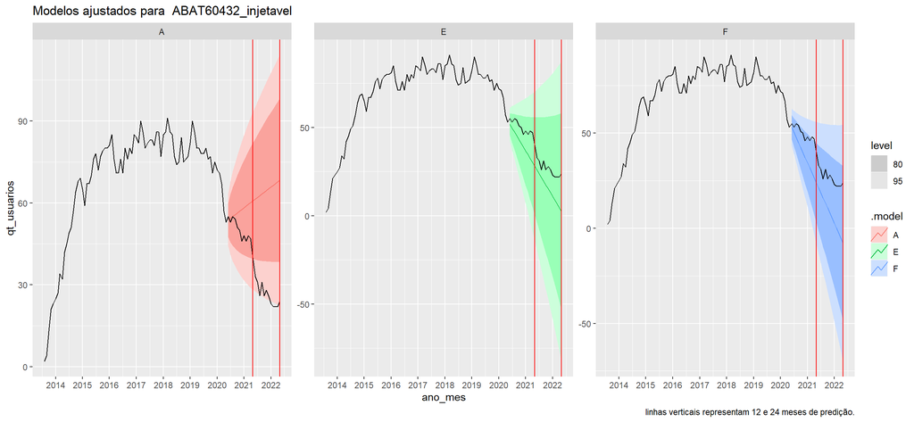

```
##
##
## Table: Modelos para ADAL60438_injetavel e suas métricas.
##
## |key                 |.model |metrica |      v.0|       v.12|       v.24|
## |:-------------------|:------|:-------|--------:|----------:|----------:|
## |ADAL60438_injetavel |A      |REQM    | 17.01856|   87.38503|   72.19083|
## |ADAL60438_injetavel |C      |REQM    | 12.33477|   82.48185|   71.97500|
## |ADAL60438_injetavel |F      |REQM    | 18.38782|   89.84385|   69.93844|
## |ADAL60438_injetavel |A      |winkler |      NaN|  731.72688|  482.73639|
## |ADAL60438_injetavel |C      |winkler |      NaN|  713.42103|  511.83214|
## |ADAL60438_injetavel |F      |winkler |      NaN| 1083.68629| 2443.63308|
```

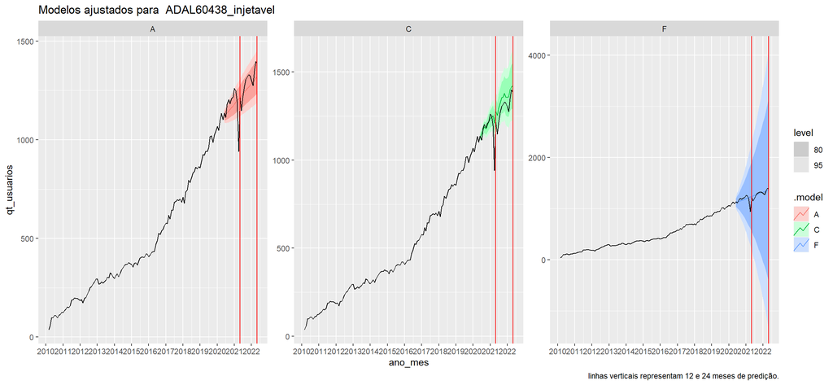

```
##
##
## Table: Modelos para ETAN60438_injetavel e suas métricas.
##
## |key                 |.model |metrica |      v.0|      v.12|       v.24|
## |:-------------------|:------|:-------|--------:|---------:|----------:|
## |ETAN60438_injetavel |C      |REQM    | 16.58825|  76.71525|  150.94501|
## |ETAN60438_injetavel |D      |REQM    | 21.42417|  55.15243|  108.66253|
## |ETAN60438_injetavel |F      |REQM    | 30.51275|  29.33087|   38.78398|
## |ETAN60438_injetavel |C      |winkler |      NaN| 622.25893| 1670.14981|
## |ETAN60438_injetavel |D      |winkler |      NaN| 220.33266|  321.22205|
## |ETAN60438_injetavel |F      |winkler |      NaN| 761.18273| 1761.34524|
```

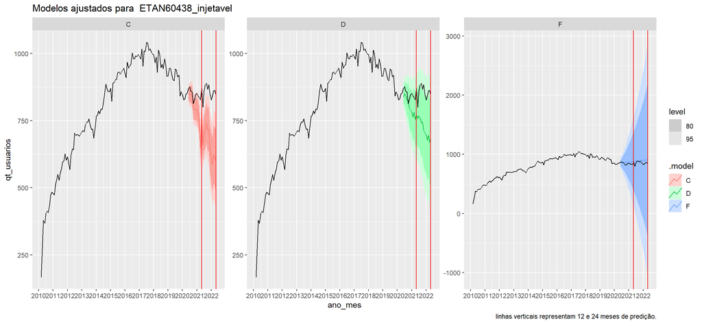

```
##
##
## Table: Modelos para INFL60438_injetavel e suas métricas.
##
## |key                 |.model |metrica |      v.0|      v.12|      v.24|
## |:-------------------|:------|:-------|--------:|---------:|---------:|
## |INFL60438_injetavel |C      |REQM    | 5.127377|  6.917791|  7.049519|
## |INFL60438_injetavel |E      |REQM    | 6.052116| 10.684819| 16.382102|
## |INFL60438_injetavel |C      |winkler |      NaN| 44.822495| 59.291864|
## |INFL60438_injetavel |E      |winkler |      NaN| 41.459009| 54.136623|
```

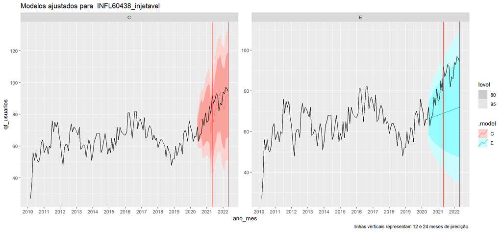

```
##
##
## Table: Modelos para LEFL60432_oral e suas métricas.
##
## |key            |.model |metrica |      v.0|      v.12|      v.24|
## |:--------------|:------|:-------|--------:|---------:|---------:|
## |LEFL60432_oral |A      |REQM    | 25.72104|  26.44473|  34.44917|
## |LEFL60432_oral |B      |REQM    | 25.72364|  26.39693|  34.42145|
## |LEFL60432_oral |E      |REQM    | 26.49866|  26.68990|  33.99152|
## |LEFL60432_oral |A      |winkler |      NaN| 251.78923| 347.51470|
## |LEFL60432_oral |B      |winkler |      NaN| 247.79938| 341.56720|
## |LEFL60432_oral |E      |winkler |      NaN| 242.00720| 331.34890|
```

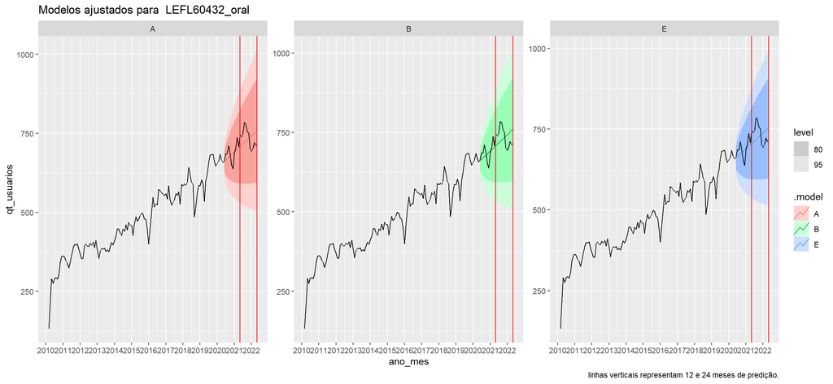

```
##
##
## Table: Modelos para METO60453_injetavel e suas métricas.
##
## |key                 |.model |metrica |      v.0|      v.12|      v.24|
## |:-------------------|:------|:-------|--------:|---------:|---------:|
## |METO60453_injetavel |A      |REQM    | 20.60383|  48.80744|  55.37442|
## |METO60453_injetavel |E      |REQM    | 20.67257|  48.54738|  54.19762|
## |METO60453_injetavel |A      |winkler |      NaN| 190.48709| 295.73378|
## |METO60453_injetavel |E      |winkler |      NaN| 192.12173| 291.54029|
```

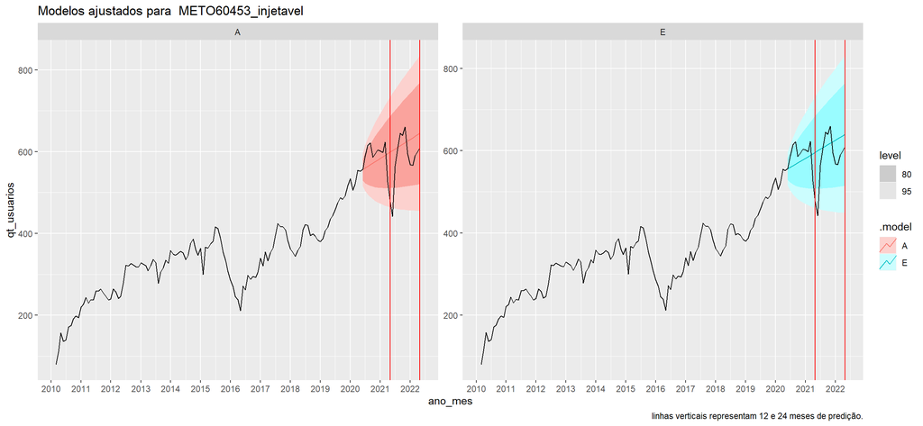

```
##
##
## Table: Modelos para METO60453_oral e suas métricas.
##
## |key            |.model |metrica |      v.0|      v.12|      v.24|
## |:--------------|:------|:-------|--------:|---------:|---------:|
## |METO60453_oral |B      |REQM    | 21.59023|  25.38344|  32.78034|
## |METO60453_oral |E      |REQM    | 21.62407|  25.17649|  32.79930|
## |METO60453_oral |B      |winkler |      NaN| 182.78742| 247.85088|
## |METO60453_oral |E      |winkler |      NaN| 185.33649| 251.68615|
```

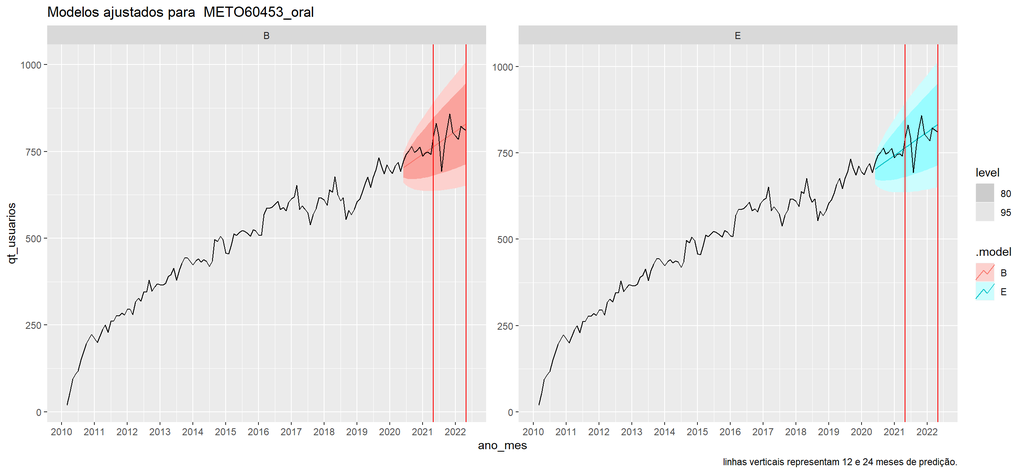

```
##
##
## Table: Modelos para TOCI60469_injetavel e suas métricas.
##
## |key                 |.model |metrica |      v.0|      v.12|      v.24|
## |:-------------------|:------|:-------|--------:|---------:|---------:|
## |TOCI60469_injetavel |B      |REQM    | 10.01961|  18.52237|  24.43091|
## |TOCI60469_injetavel |E      |REQM    | 10.68344|  18.71588|  24.51641|
## |TOCI60469_injetavel |F      |REQM    | 10.96624|  12.20606|  12.94193|
## |TOCI60469_injetavel |B      |winkler |      NaN| 100.98053| 112.04630|
## |TOCI60469_injetavel |E      |winkler |      NaN|  70.40179|  90.92757|
## |TOCI60469_injetavel |F      |winkler |      NaN| 228.48637| 353.64867|
```

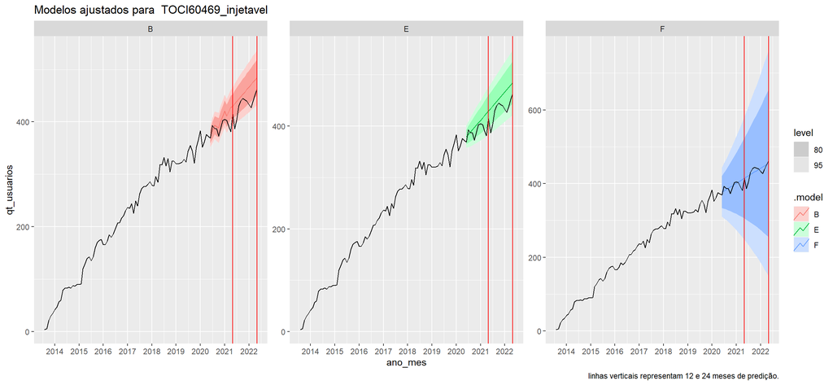

```r
for(i in unique(meds$key)){
  aux <- mm.f.acc %>%
    filter(key == i) %>%
    group_by(key, metrica) %>%
    slice_min(v.0, na_rm = T) %>%
    ungroup() %>%
    union(mm.f.acc %>%
            filter(key == i) %>%
            group_by(key, metrica) %>%
            slice_min(v.12, na_rm = T) %>%
            ungroup()) %>%
    union(mm.f.acc %>%
            filter(key == i) %>%
            group_by(key, metrica) %>%
            slice_min(v.24, na_rm = T) %>% ungroup) %>%
    select(key, .model) %>%
    unique()

  aux %>%
    inner_join(mm.f.acc, by = c("key", ".model")) %>%
    arrange(key, metrica, .model) %>%
    knitr::kable(caption = paste("Modelos para", i, "e suas métricas.")) %>%
    # knitr::kable(caption = paste("Modelos para", i, "e suas métricas."), format = "latex") %>%
    print()

  print(
    meds.cast.24 %>%
      inner_join(aux, by = c("key", ".model")) %>%
      autoplot(meds) +
      scale_x_yearmonth(date_breaks = '1 year', date_labels='%Y') +
      facet_wrap( ~ .model, scales = "free") +
      geom_vline(xintercept = as.Date(max(
        meds.treino$ano_mes
      ) + c(12, 24)), colour = "red") +
      labs(title = paste("Modelos ajustados para ", i),
           caption = "linhas verticais representam 12 e 24 meses de predição.")
  )
}
```

Já as tabelas e gráficos acima apresentam somente os modelos com os melhores REQM e escore Winkler. Sendo eles:

### Adalimumabe

Adalimumabe tem uma especificidade nos dados observados até 12 meses, em que há uma queda brusca no número de pacientes. Esta queda não foi explicada durante a análise e foi julgada imprevisível. Isto posto, os três melhores ajustes quanto ao REQM foram os modelos A (modelo proposto ARIMA(1,1,0) com drift), C (LM com erros ARIMA(0,2,2)) e F (suavização exponencial com erros multiplicativos). Entre eles, o modelo C teve os melhores REQMs para a base de treino (12.33477) e para doze meses (82.48185), ficando em segundo lugar entre os três para 24 meses (71.97500). Por outro lado, o modelo F foi o contrário, obtendo o melhor REQM para 24 meses (69.93844), mas ficando para trás nos outros dois períodos (18.38782 na base de teste e 89.84385 para doze meses). Sendo assim, e analisando os gráficos dos ajustes, sugere-se o uso do modelo C para a predição do número de pacientes de atrite idiopática juvenil tratados com adalimumabe. Contudo, sugere-se cautela e comparação com resultados do modelo A, pois o modelo C depende de informações desconhecidas no momento da predição como a quantidade total de pacientes tratados no SUS com medicamentos do CEAF 1a. Estes dados podem ser preditos usando a estratégia proposta para a demanda aferida, mas isso incorre maior incerteza ao modelo.

### Etanercepte

Etanercepte teve uma queda no número de pacientes começando por volta de 2017. Ao final da série de treino, os números não tinham estabilizado ainda, o que só ocorreu nos meses seguintes. Tendo este comportamento diferente do restante da série, era de se esperar que os modelos não fossem capazes de predizer os números observados. Contudo, apesar de os modelos estimarem médias decrescentes que se distanciam do observado, o modelo D (modelo de decomposição trend + remainder com trend modelado usando LM com erros ARIMA e os parametros qt_concorrentes e qt_total_usuarios) foi capaz de manter os 12 primeiros meses observados dentro de seu intervalo preditivo. O modelo D se destaca quando observado seu escore winkler (220.33266 para 12 meses e 321.22205 para 24 contra 622.25893 e 1670.14981 para os mesmos periodos do modelo C). Isto posto, sugere-se o uso do modelo D para a estimativa de número de pacientes usuários de etanercepte, limitado a 12 meses e tomado o cuidado de considerar a incerteza inerente ao uso de dados estimados para o parâmetro qt_total_usuarios. Finalmente, tendo estabilizado o comportamento da difusão, é possível que um novo ajuste com os dados mais recentes tenha melhor desempenho em predizer números futuros.

### Infliximabe

Os escores dos dois melhores modelos para infliximabe foram próximos. Ambos intervalos preditivos incluíram números entre 40 e 110 pacientes, sem apresentar dados observados fora dos intervalos. Por outro lado, os REQMs do modelo C (ML com erros ARIMA(2,0,1)) foram melhores em todos os intervalos avaliados (base de teste, 12 e 24 meses) quando comparados aos REQM do modelo E (suavização exponencial de Holt). Percebe-se também, pelo gráfico, que a média estimada pela suavização exponencial subestima os valores observados no período. Deve-se, contudo, ter cautela no uso do modelo, pois depende de dados desconhecidos no momento da estimativa, se apoiando em números estimados para a quantidade total de pacientes de AIJ.

### Metotrexato injetável

Apesar de um crescimento relativamente estável no número de pacientes, houve duas ocasiões de queda brusca, uma entre 2015 e 2016 e outra 2021. Os modelos mais bem ajustados foram incapazes de predizer a queda de 2021, visto que é um acontecimento incomum. Tanto os gráficos quanto as métricas dos modelos A (modelo proposto ARIMA(1,1,0) com drift) e E (suavização exponencial de Holt) são bastante parecidos, sugerindo que ambos os modelos possam ser usados de maneira intercambiável. Seus REQM tiveram médias 20.6382, 48.67741 e 54.78602 quando avaliados na base de treino, em doze e 24 meses respectivamente, e desvios padrão 0.04860652, 0.1838902 e 0.8321233 para os mesmos períodos, sendo que o modelo E teve os menores REQMs para as bases de validação. Ao mesmo tempo, seus escores tiveram médias 191.3044 e 293.637 para doze e 24 meses, respectivamente, e desvios padrão 1.155865 e 2.965245 para os mesmos períodos, sendo o modelo A o com menor escore para doze meses e o E para 24. Isto posto, pode-se usar qualquer um dos modelos A ou E para a predição do número de pacientes tratados com metotrexato injetável.

### Metotrexato oral

A difusão de metotrexato oral é parecida com a de metotrexato injetável, porém sem quedas bruscas. Tanto o modelo B (ARIMA(0,1,1) com drift) quanto O modelo E (suavização exponencial de Holt) tiveram bons desempenhos, bastante próximos entre eles. Isto sugere que possam ser usados intercambiavelmente. Quanto às métricas, os REQMs tiveram desvio padrão de 0.02392849 para a base de treino, 0.1463357 para doze meses e 0.01340674 para 24 meses, sendo que as médias nesses períodos foram de 21.60715, 25.27997 e 32.78982, entre os dois modelos. Finalmente, sugere-se o uso de qualquer um dos dois modelos, pois têm desempenhos parecidos.

### Tocilizumabe

Os REQMs do modelo F (suavização exponencial com erros multiplicativos) foram os mais baixos avaliados na base de validação (12 e 24 meses), contudo, teve os piores escores no mesmo período devido ao largo intervalo preditivo. Por outro lado, ambos os modelos B (ARIMA(1,1,1)(0,0,1)[12] com drift) e E (suavização exponencial de Holt) obtiveram REQMs e escores bastante parecidos. Em média, estes modelos tiveram REQM 10.35152, 18.61912 e 24.47366 para base de treino, doze e 24 meses, respectivamente. Sendo que o modelo B teve o menor REQM entre os dois em todos os três períodos, com desvios padrão 0.4693987, 0.1368322 e 0.06045763, na mesma ordem. Entre os modelos ajustados, contudo, os melhores escores foram os do modelo E, com 70.40179 para doze meses, contra 100.98053 do modelo B e 90.92757 em 24 meses contra 112.04630 do B. Sugere-se o uso do modelo E, apesar de não ter as melhores estimativas pontuais, pelo menor intervalo preditivo.

```r
save.image(file = "M08.RData")
```

# Conclusões

Para a modelagem da demanda aferida, sugere-se o uso do modelo C (suavização exponencial de Holt).

Para abatacepte, sugere-se o uso do modelo E (suavização exponencial de Holt), com a ressalva de se estimar somente 12 meses e repetir a estimativa com a obtenção de dados mais recentes quando possível.

Sugere-se o uso do modelo C (LM com erros ARIMA(0,2,2)) ou o modelo proposto A na predição de usuários de adalimumabe. Contudo, a predição deve ser realizada com cautela, pois o modelo C depende de quantidades desconhecidas, que devem ser obtidas a partir de um modelo para a demanda aferida.

Para etanercepte, somente o modelo D foi capaz de abarcar os dados observados em seu intervalo preditivo de forma satisfatória (escore baixo). Ainda assim, apresenta a fragilidade de depender de um dado estimado para a demanda total. Sendo assim, devem-se considerar margens mais largas para a predição.

O modelo sugerido para infliximabe tem a mesma fragilidade que os selecionados para adalimumabe e etanercepte, dependendo da demanda aferida. Mesmo assim, o modelo C (ML com erros ARIMA(2,0,1)) teve um bom desempenho ao estimar números de pacientes até 24 meses, usando o número total de pacientes conhecido.

Tanto para metotrexato injetável quanto para o oral, o modelo E (suavização exponencial de Holt) foi um bom candidato. Para a forma injetável, pode-se usar também o modelo proposto A (ARIMA(1,1,0) com drift) e para o oral o modelo B (ARIMA(0,1,1) com drift), sem prejuízo.

Finalmente, para tocilizumabe, sugere-se o uso da suavização exponencial de Holt, modelo E. Este modelo, apesar de não ter a melhor aproximação da média, conteve a maior parte das observações em um intervalo preditivo mais enxuto que o modelo F, que teve melhores estimativas de média.